# 432 Class 19

Thomas E. Love, Ph.D.

2024-03-26

## Today’s Topic

**Multinomial Logistic Regression: An Introduction**

- Two Examples about Alligators
- Fitting Multinomial Logistic Regression Models

Chapter 28 of the Course Notes describes an additional example discussing this material.

## Setup

```r
knitr::opts_chunk$set(comment=NA)
options(width = 60)

library(janitor)
library(broom)
library(mosaic)
library(gt)
library(naniar)
library(nnet)
library(rms)
library(conflicted)
library(tidyverse)

conflicts_prefer(base::mean, dplyr::filter, dplyr::select, dplyr::summarize)

theme_set(theme_bw())
```

## Regression on Multi-categorical Outcomes

Suppose we have a nominal, multi-categorical outcome of interest. Multinomial (also called multicategory or polychotomous) logistic regression models describe the odds of response in one category instead of another.

- Such models pair each outcome category with a baseline category, the choice of which is arbitrary.
- The model consists of J-1 logit equations (for an outcome with J categories) with separate parameters for each.

# A small example: `gator1` on Alligator Food Choices

## Today’s Data

Today’s data relates to alligator food choices. We’ll actually work with two different data sets.

In each case, we’ll read in the data, and set some key variables to be factors and, if needed, actively select the baseline category.

## `gator1`: Alligator Food Choice

The `gator1` data are from a study by the Florida Game and Fresh Water Fish Commission of factors influencing the primary food choice of alligators<sup>1</sup>.

We’ll be trying to predict primary food `choice` using the alligator’s `length`.

[^1]: Source: Agresti’s 1996 first edition of An Introduction to Categorical Data Analysis, Table 8.1. These were provided by Delany MF and Moore CT.

## `gator1` has data on 59 alligators

- `length` (in meters)
- `choice` = primary food type, in volume, found in the alligator’s stomach, specifically…
  - Fish,
  - Invertebrates (mostly apple snails, aquatic insects and crayfish, and I’ll abbreviate this category as `Inverts` in what follows)
  - Other (which includes reptiles, amphibians, mammals, plant material and stones or other debris.)

## Ingesting the `gator1` data

```r
gator1 <- read_csv("c19/data/gator1.csv",
                   show_col_types = FALSE) |>
    mutate(choice = fct_relevel(factor(choice), "Other"),
           choice = fct_recode(choice,
                               "Inverts" = "Invertebrates"))

gator1
```

```
# A tibble: 59 × 3
      id length choice
   <dbl>  <dbl> <fct>
 1     1   1.24 Inverts
 2     2   1.3  Inverts
 3     3   1.3  Inverts
 4     4   1.32 Fish
 5     5   1.32 Fish
 6     6   1.4  Fish
 7     7   1.42 Inverts
 8     8   1.42 Fish
 9     9   1.45 Inverts
10    10   1.45 Other
# ℹ 49 more rows
```

## Summarizing `length` by `choice`

Note that I’ve set up `choice` so that “Other” is the baseline (first) category, while ingesting the data.

```r
favstats(length ~ choice, data = gator1) |>
  gt() |> fmt_number(min:sd, decimals = 2) |>
  tab_options(table.font.size = 20)
```

| choice | min | Q1 | median | Q3 | max | mean | sd | n | missing |
| --- | --- | --- | --- | --- | --- | --- | --- | --- | --- |
| Other | 1.45 | 1.71 | 2.17 | 3.26 | 3.68 | 2.42 | 0.88 | 8 | 0 |
| Fish | 1.32 | 1.74 | 2.31 | 2.73 | 3.89 | 2.36 | 0.76 | 31 | 0 |
| Inverts | 1.24 | 1.47 | 1.61 | 1.78 | 2.72 | 1.66 | 0.33 | 20 | 0 |

There is no missing data in `gator1`.

```r
n_miss(gator1)
```

```
[1] 0
```

## Length and Primary Food Choice

```r
ggplot(gator1, aes(x = choice, y = length, fill = choice)) +
  geom_violin() +
  geom_boxplot(fill = "white", col = "black", width = 0.1) +
  scale_fill_brewer(palette = "Set1") + guides(fill = "none")
```

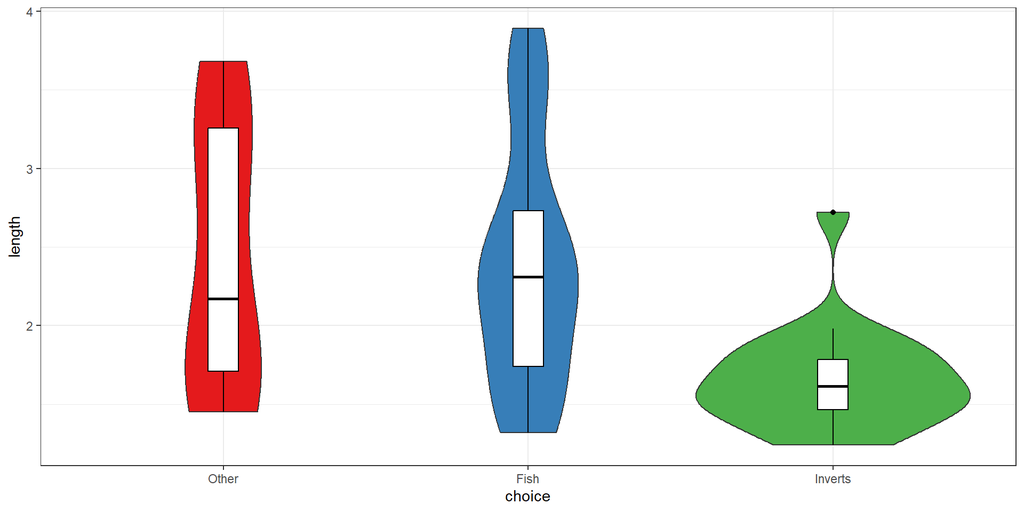

# Fitting a Multinomial Logistic Regression

## Multinomial Logistic Regression Fit

- “Other” is the first (reference) level for `choice`

```r
gator1 |> tabyl(choice)
```

```
  choice  n   percent
   Other  8 0.1355932
    Fish 31 0.5254237
 Inverts 20 0.3389831
```

Let’s try using `multinom()` from the `nnet` package

```r
try1 <- multinom(choice ~ length, data=gator1)
```

## Looking over the first try

```r
try1
```

```
Call:
multinom(formula = choice ~ length, data = gator1)

Coefficients:
        (Intercept)     length
Fish       1.617952 -0.1101836
Inverts    5.697543 -2.4654695

Residual Deviance: 98.34124
AIC: 106.3412
```

Our R output suggests the following models:

- log odds of Fish rather than Other = 1.62 - 0.110 Length
- log odds of Inverts. rather than Other = 5.70 - 2.465 Length

## Estimating Response Probabilities

We can express the multinomial logistic regression model directly in terms of outcome probabilities:

$$\pi_j = \frac{exp(\beta_{0j} + \beta_{1j} x)}{\Sigma_j exp(\beta_{0j} + \beta_{1j} x)}$$

Our models contrast “Fish” and “Invertebrates” to “Other” as the reference category.

## Estimating Response Probabilities

$$\pi_j = \frac{exp(\beta_{0j} + \beta_{1j} x)}{\Sigma_j exp(\beta_{0j} + \beta_{1j} x)}$$

In our `try1`, we have:

- log odds of Fish rather than Other = 1.62 - 0.110 Length
- log odds of Inverts rather than Other = 5.70 - 2.465 Length
- For the reference category we use $\beta_{0j} = 0$ and $\beta_{1j} = 0$ so that $exp(\beta_{0j} + \beta_{1j} x) = 1$ for that category (here, Other.)

## `try1` Response Probabilities

Our estimates (which will sum to 1) are:

$$Pr(Fish | Length = L) =
\frac{exp(1.62 - 0.110 L)}{1 + exp(1.62 - 0.110 L) + exp(5.70 - 2.465 L)}$$

$$Pr(Invert. | Length = L) =
\frac{exp(5.70 - 2.465 L)}{1 + exp(1.62 - 0.110 L) + exp(5.70 - 2.465 L)}$$

$$Pr(Other | Length = L) =
\frac{1}{1 + exp(1.62 - 0.110 L) + exp(5.70 - 2.465 L)}$$

## Making a Prediction with `try1`

For an alligator of 3.9 meters, for instance, we have:

$$denominator = {1 + exp(1.62 - 0.110 (3.9)) + exp(5.70 - 2.465 (3.9))} = 4.31 \\
Pr(Fish) = \frac{exp(1.62 - 0.110 (3.9))}{4.31} = \frac{3.29}{4.31} = 0.7633\\
Pr(Invert.) = \frac{exp(5.70 - 2.465 (3.9)}{4.31} = \frac{0.02}{4.31} = 0.0046\\
Pr(Other) = \frac{1}{4.31} = 0.2320$$

## Predicted Probabilities from `try1`

```r
try1_fits <-
    predict(try1, newdata = gator1, type = "probs")

gator1_try1 <- cbind(gator1, try1_fits)

head(gator1_try1); tail(gator1_try1)
```

```
  id length  choice      Other      Fish   Inverts
1  1   1.24 Inverts 0.05150117 0.2265417 0.7219571
2  2   1.30 Inverts 0.05727232 0.2502677 0.6924600
3  3   1.30 Inverts 0.05727232 0.2502677 0.6924600
4  4   1.32    Fish 0.05927999 0.2584705 0.6822495
5  5   1.32    Fish 0.05927999 0.2584705 0.6822495
6  6   1.40    Fish 0.06770167 0.2925999 0.6396985
```

```
   id length choice     Other      Fish     Inverts
54 54   3.56   Fish 0.2245916 0.7650815 0.010326935
55 55   3.58   Fish 0.2250825 0.7650659 0.009851557
56 56   3.66   Fish 0.2270070 0.7648358 0.008157239
57 57   3.68  Other 0.2274793 0.7647398 0.007780920
58 58   3.71   Fish 0.2281817 0.7645698 0.007248494
59 59   3.89   Fish 0.2322725 0.7629934 0.004734037
```

## Tabulating Response Probabilities

```r
gator1_try1 |> group_by(choice) |>
    summarise(mean(Other), mean(Fish), mean(Inverts))
```

```
# A tibble: 3 × 4
  choice  `mean(Other)` `mean(Fish)` `mean(Inverts)`
  <fct>           <dbl>        <dbl>           <dbl>
1 Other          0.155         0.580           0.265
2 Fish           0.155         0.590           0.255
3 Inverts        0.0973        0.404           0.499
```

## Pivot the Wide data to make it longer

We need to have this data organized differently in order to build the plot I want to build.

```r
gator1_try1long <-
  pivot_longer(gator1_try1,
               cols = c("Other", "Fish", "Inverts"),
               names_to = "preference",
               values_to = "probability") |>
  mutate(preference = factor(preference))
```

## What does this pivoting accomplish?

```r
gator1_try1long
```

```
# A tibble: 177 × 5
      id length choice  preference probability
   <dbl>  <dbl> <fct>   <fct>            <dbl>
 1     1   1.24 Inverts Other           0.0515
 2     1   1.24 Inverts Fish            0.227
 3     1   1.24 Inverts Inverts         0.722
 4     2   1.3  Inverts Other           0.0573
 5     2   1.3  Inverts Fish            0.250
 6     2   1.3  Inverts Inverts         0.692
 7     3   1.3  Inverts Other           0.0573
 8     3   1.3  Inverts Fish            0.250
 9     3   1.3  Inverts Inverts         0.692
10     4   1.32 Fish    Other           0.0593
# ℹ 167 more rows
```

## `try1` Response Probabilities

```r
ggplot(gator1_try1long, aes(x = length, y = probability,
                            col = preference)) +
    geom_line(size = 2) + scale_fill_brewer(palette = "Set1")
```

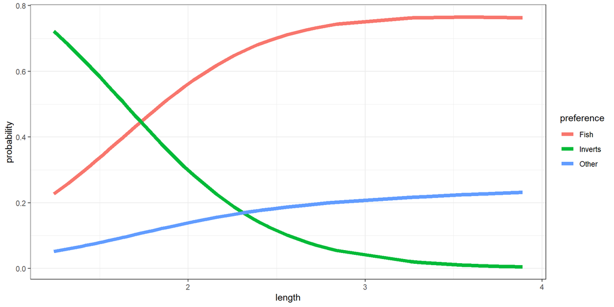

## `try1` model summary

```r
summary(try1)
```

```
Call:
multinom(formula = choice ~ length, data = gator1)

Coefficients:
        (Intercept)     length
Fish       1.617952 -0.1101836
Inverts    5.697543 -2.4654695

Std. Errors:
        (Intercept)    length
Fish       1.307291 0.5170838
Inverts    1.793820 0.8996485

Residual Deviance: 98.34124
AIC: 106.3412
```

```r
glance(try1) |> gt() |> tab_options(table.font.size = 20)
```

| edf | deviance | AIC | nobs |
| --- | --- | --- | --- |
| 4 | 98.34124 | 106.3412 | 59 |

## Compare to intercept-only model

Compare `try1` to the null model with only an intercept (`try0`)

```r
try0 <- multinom(choice ~ 1, data=gator1)
AIC(try0, try1)
```

```
     df      AIC
try0  2 119.1419
try1  4 106.3412
```

```r
BIC(try0, try1)
```

```
     df      BIC
try0  2 123.2969
try1  4 114.6514
```

Does the inclusion of `length` produce a meaningfully better fit to the data than simply fitting an intercept?

## ANOVA for `try0` vs. `try1`

- If you’d prefer a hypothesis testing approach, use `anova`…

```r
anova(try0, try1)
```

```
Likelihood ratio tests of Multinomial Models

Response: choice
   Model Resid. df Resid. Dev   Test    Df LR stat.
1      1       116  115.14186
2 length       114   98.34124 1 vs 2     2 16.80061
       Pr(Chi)
1
2 0.0002247985
```

Does the inclusion of `length` produce a meaningfully better fit to the data than simply fitting an intercept?

## Wald Z tests for individual predictors

```r
tidy(try1) |>
  gt() |> fmt_number(decimals = 3) |>
  tab_options(table.font.size = 20)
```

| y.level | term | estimate | std.error | statistic | p.value |
| --- | --- | --- | --- | --- | --- |
| Fish | (Intercept) | 1.618 | 1.307 | 1.238 | 0.216 |
| Fish | length | −0.110 | 0.517 | −0.213 | 0.831 |
| Inverts | (Intercept) | 5.698 | 1.794 | 3.176 | 0.001 |
| Inverts | length | −2.465 | 0.900 | −2.740 | 0.006 |

# Working with a larger example: `gator2`

## `gator2` describes 219 alligators

The `gator2.csv` data<sup>1</sup> considers the stomach contents of 219 alligators, aggregated into 5 categories by primary food choice:

- fish
- invertebrates
- reptiles
- birds
- other (including amphibians, plants, household pets, stones, and debris)
[^2]: Source: https://online.stat.psu.edu/stat504/lesson/8

## `gator2` has additional predictors

The 219 alligators are also categorized by:

- sex (m or f), and
- by length (< 2.3 and $\geq$ 2.3 meters) and
- by which of four lakes they were captured in (Hancock, Oklawaha, Trafford or George.)

We’ll use as our baseline: fish as a `choice`, sex as `m`, length `>= 2.3` and lake `george`.

See the Table on next slide.

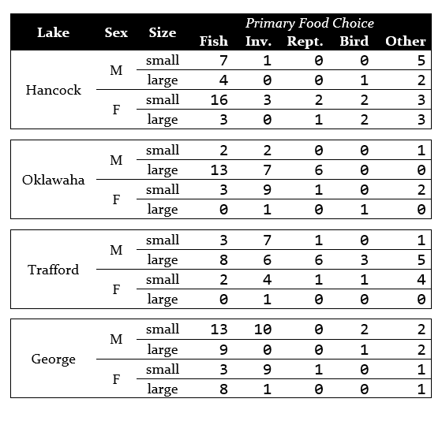

## Model Setup

$$\pi_1 = Pr(Fish), \pi_2 = Pr(Invert.), \pi_3 = Pr(Reptiles),$$
$$\pi_4 = Pr(Birds), \pi_5 = Pr(Other)$$

We’ll use Fish as the baseline, so our regression equations take the form

$$log(\frac{\pi_j}{\pi_1}) = \beta_0 + \beta_1[Lake=Hancock] + \beta_2[Lake=Oklawaha] +$$
$$\beta_3[Lake=Trafford] + \beta_4[Length \geq 2.3] + \beta_5[Sex = Female]$$

for $j = 2, 3, 4, 5$.

## How many coefficients do we estimate?

- We have six coefficients to estimate in each of four logit equations (one each for $j = 2, 3, 4, 5$) so there are 24 parameters to estimate.

## Ingesting the `gator2` data

```r
gator2 <- read_csv("c19/data/gator2.csv", show_col_types = FALSE) |>
    mutate(across(where(is_character), as_factor),
           id = as.character(id))
```

We re-level the factors to put our reference categories first.

```r
gator2 <- gator2 |>
    mutate(food = fct_relevel(food, "fish", "invert",
                            "rep", "bird", "other"),
           size = fct_relevel(size, ">=2.3"),
           gender = fct_relevel(gender, "m"),
           lake = fct_relevel(lake, "george"))

summary(gator2 |> select(-id))
```

```
     food       size     gender        lake
 fish  :94   >=2.3: 95   m:130   george  :63
 invert:61   <2.3 :124   f: 89   hancock :55
 rep   :19                       oklawaha:48
 bird  :13                       trafford:53
 other :32
```

## The Models We Will Fit

We’ll fit (using `multinom()` from `nnet`)

- A *saturated* model, including all three predictors and all two-way interactions and the three-way interaction
- A *null* model, with the intercept alone
- Simple logistic regression models for each of the three predictors as a main effect alone
- The model including both L(ake) and S(ize) but nothing else
- The model including all three predictors as main effects, but no interactions

## The Models We Will Fit (code only)

```r
options(contrasts=c("contr.treatment", "contr.poly"))
fit_SAT <- multinom(food ~ lake*size*gender, data=gator2) # saturated
fit_1 <-multinom(food~1,data=gator2)                # null
fit_G <-multinom(food~gender,data=gator2)           # G
fit_L <-multinom(food~lake,data=gator2)             # L
fit_S <-multinom(food~size,data=gator2)             # S
fit_LS <-multinom(food~lake+size,data=gator2)        # L+S
fit_GLS <-multinom(food~gender+lake+size,data=gator2) # G+L+S
```

## What You’ll See When Fitting the models

```r
options(contrasts=c("contr.treatment", "contr.poly"))
fit_SAT <- multinom(food ~ lake*size*gender, data=gator2)
```

[output not shown]

and we’ll see something similar for each of the other models…

## The Intercept only Model `fit_1`

```r
summary(fit_1)
```

```
Call:
multinom(formula = food ~ 1, data = gator2)

Coefficients:
       (Intercept)
invert  -0.4324211
rep     -1.5988558
bird    -1.9783458
other   -1.0775589

Std. Errors:
       (Intercept)
invert   0.1644133
rep      0.2515350
bird     0.2959078
other    0.2046663

Residual Deviance: 604.3629
AIC: 612.3629
```

## Tidying this summary

```r
tidy(fit_1, exponentiate = FALSE) |>
  gt() |> fmt_number(decimals = 3) |>
  tab_options(table.font.size = 20)
```

| y.level | term | estimate | std.error | statistic | p.value |
| --- | --- | --- | --- | --- | --- |
| invert | (Intercept) | −0.432 | 0.164 | −2.630 | 0.009 |
| rep | (Intercept) | −1.599 | 0.252 | −6.356 | 0.000 |
| bird | (Intercept) | −1.978 | 0.296 | −6.686 | 0.000 |
| other | (Intercept) | −1.078 | 0.205 | −5.265 | 0.000 |

```r
glance(fit_1) |> gt() |>
  tab_options(table.font.size = 20)
```

| edf | deviance | AIC | nobs |
| --- | --- | --- | --- |
| 4 | 604.3629 | 612.3629 | 219 |

## Size only model

```r
tidy(fit_S, exponentiate = FALSE) |> gt() |>
  fmt_number(decimals = 3) |>
  tab_options(table.font.size = 20)
```

| y.level | term | estimate | std.error | statistic | p.value |
| --- | --- | --- | --- | --- | --- |
| invert | (Intercept) | −1.034 | 0.291 | −3.553 | 0.000 |
| invert | size<2.3 | 0.949 | 0.357 | 2.659 | 0.008 |
| rep | (Intercept) | −1.242 | 0.315 | −3.944 | 0.000 |
| rep | size<2.3 | −0.858 | 0.535 | −1.604 | 0.109 |
| bird | (Intercept) | −1.727 | 0.384 | −4.502 | 0.000 |
| bird | size<2.3 | −0.555 | 0.606 | −0.916 | 0.360 |
| other | (Intercept) | −1.242 | 0.315 | −3.944 | 0.000 |
| other | size<2.3 | 0.294 | 0.415 | 0.709 | 0.478 |

## Size only model

```r
glance(fit_S) |> gt() |> tab_options(table.font.size = 20)
```

| edf | deviance | AIC | nobs |
| --- | --- | --- | --- |
| 8 | 589.2134 | 605.2134 | 219 |

## Gender only model

```r
tidy(fit_G, exponentiate = FALSE) |> gt() |> fmt_number(decimals = 3) |>
  tab_options(table.font.size = 20)
```

| y.level | term | estimate | std.error | statistic | p.value |
| --- | --- | --- | --- | --- | --- |
| invert | (Intercept) | −0.581 | 0.217 | −2.673 | 0.008 |
| invert | genderf | 0.358 | 0.334 | 1.072 | 0.284 |
| rep | (Intercept) | −1.513 | 0.306 | −4.937 | 0.000 |
| rep | genderf | −0.251 | 0.538 | −0.467 | 0.641 |
| bird | (Intercept) | −2.132 | 0.400 | −5.332 | 0.000 |
| bird | genderf | 0.368 | 0.596 | 0.618 | 0.537 |
| other | (Intercept) | −1.187 | 0.269 | −4.409 | 0.000 |
| other | genderf | 0.271 | 0.415 | 0.652 | 0.514 |

## Gender only model

```r
glance(fit_G) |> gt() |> tab_options(table.font.size = 20)
```

| edf | deviance | AIC | nobs |
| --- | --- | --- | --- |
| 8 | 602.2589 | 618.2589 | 219 |

## Lake only model (part 1 of 2)

```r
tidy(fit_L, exponentiate = FALSE) |> slice(1:10) |>
  gt() |> fmt_number(decimals = 3) |>
  tab_options(table.font.size = 20)
```

| y.level | term | estimate | std.error | statistic | p.value |
| --- | --- | --- | --- | --- | --- |
| invert | (Intercept) | −0.501 | 0.283 | −1.767 | 0.077 |
| invert | lakehancock | −1.514 | 0.603 | −2.511 | 0.012 |
| invert | lakeoklawaha | 0.555 | 0.434 | 1.278 | 0.201 |
| invert | laketrafford | 0.826 | 0.461 | 1.791 | 0.073 |
| rep | (Intercept) | −3.496 | 1.015 | −3.445 | 0.001 |
| rep | lakehancock | 1.194 | 1.182 | 1.010 | 0.312 |
| rep | lakeoklawaha | 2.552 | 1.108 | 2.302 | 0.021 |
| rep | laketrafford | 3.011 | 1.110 | 2.713 | 0.007 |
| bird | (Intercept) | −2.398 | 0.603 | −3.976 | 0.000 |
| bird | lakehancock | 0.607 | 0.773 | 0.785 | 0.432 |

## Lake only model (part 2 of 2)

```r
tidy(fit_L, exponentiate = FALSE) |> slice(11:16) |>
  gt() |> fmt_number(decimals = 3) |>
  tab_options(table.font.size = 20)
```

| y.level | term | estimate | std.error | statistic | p.value |
| --- | --- | --- | --- | --- | --- |
| bird | lakeoklawaha | −0.492 | 1.191 | −0.413 | 0.680 |
| bird | laketrafford | 1.220 | 0.831 | 1.468 | 0.142 |
| other | (Intercept) | −1.705 | 0.444 | −3.841 | 0.000 |
| other | lakehancock | 0.869 | 0.554 | 1.567 | 0.117 |
| other | lakeoklawaha | −0.087 | 0.765 | −0.114 | 0.910 |
| other | laketrafford | 1.443 | 0.611 | 2.359 | 0.018 |

```r
glance(fit_L) |> gt() |> tab_options(table.font.size = 20)
```

| edf | deviance | AIC | nobs |
| --- | --- | --- | --- |
| 16 | 561.1677 | 593.1677 | 219 |

## The Saturated Model

```r
fit_SAT
```

```
Call:
multinom(formula = food ~ lake * size * gender, data = gator2)

Coefficients:
       (Intercept) lakehancock lakeoklawaha laketrafford
invert  -22.731435  -7.6997047     22.11245    22.443706
rep     -29.030622   4.5446124     28.25748    28.742943
bird     -2.196705   0.8106289    -18.76043     1.215771
other    -1.503884   0.8107459    -25.23128     1.033839
         size<2.3     genderf lakehancock:size<2.3
invert 22.4691578  20.6519880            6.0160287
rep    -2.1497924  -1.5018889          -15.0175978
bird    0.3248760 -17.2683965          -22.8201143
other  -0.3675892  -0.5756885            0.7242536
       lakeoklawaha:size<2.3 laketrafford:size<2.3
invert             -21.85028           -21.3342850
rep                -17.43950             1.3387310
bird               -25.18859           -25.8829682
other               26.40938            -0.2614093
       lakehancock:genderf lakeoklawaha:genderf
invert           -3.946342             4.226498
rep              24.889170           -13.585689
bird             18.248790            62.485154
other             1.268734            -1.758853
       laketrafford:genderf size<2.3:genderf
invert            25.465169      -19.2913107
rep              -18.078274       31.5836415
bird              16.978562        0.6638064
other             -7.586589        1.3479978
       lakehancock:size<2.3:genderf
invert                     2.857688
rep                      -15.396895
bird                      20.157737
other                     -3.378585
       lakeoklawaha:size<2.3:genderf
invert                     -4.488351
rep                         2.767887
bird                      -24.265617
other                       1.274620
       laketrafford:size<2.3:genderf
invert                    -26.979637
rep                       -11.597631
bird                       25.472087
other                       8.606604

Residual Deviance: 487.6018
AIC: 615.6018
```

## Building a Model Comparison Table

For a model `fitX`, we find the:

- Effective degrees of freedom with `fitX$edf`
- Deviance with `deviance(fitX)` or by listing or summarizing the model
- AIC and BIC with `AIC(fitX)` and `BIC(fitX)`

```r
fit_SAT$edf; deviance(fit_SAT); AIC(fit_SAT); BIC(fit_SAT)
```

```
[1] 64
```

```
[1] 487.6018
```

```
[1] 615.6018
```

```
[1] 832.5024
```

Note that for these models, AIC = Deviance + 2(`edf`)

## Results across all models we’ve fit

[output not shown]

Which model looks like it fits the data best?

## Drop in deviance tests (example 1)

Compare Model `G` to intercept-only

```r
anova(fit_G, fit_1)
```

```
Likelihood ratio tests of Multinomial Models

Response: food
   Model Resid. df Resid. Dev   Test    Df LR stat.
1      1       872   604.3629
2 gender       868   602.2589 1 vs 2     4 2.104069
    Pr(Chi)
1
2 0.7166248
```

## Drop in deviance tests (example 2)

Compare Model `SAT` to Model `GLS`

```r
anova(fit_SAT, fit_GLS)
```

```
Likelihood ratio tests of Multinomial Models

Response: food
                 Model Resid. df Resid. Dev   Test    Df
1 gender + lake + size       852   537.8655
2 lake * size * gender       812   487.6018 1 vs 2    40
  LR stat.   Pr(Chi)
1
2 50.26368 0.1281851
```

## Results of testing

| `fit` | Model | `edf` | Deviance | versus | *p* |
| --- | --- | --- | --- | --- | --- |
| `1` | Intercept only | 4 | 604.4 | – | – |
| `G` | Gender only | 8 | 602.3 | 1 | 0.717 |
| `S` | Size only | 8 | 589.2 | 1 | 0.004 |
| `L` | Lake only | 16 | 561.2 | 1 | 0 |
| `LS` | Lake and Size | 20 | 540.1 | L | 0 |
| `GLS` | G, L, S main effects | 24 | 537.9 | LS | 0.696 |
| `SAT` | `G*S*L` (saturated) | 64 | 487.6 | GLS | 0.128 |

## Which model fits the data best?

The model with the lowest AIC is the model which collapses on Gender, and uses only Lake and Size as predictors for Food Choice. (`fit_LS`).

- This (`fit_LS`) is also the model which has the most evidence in its favor from the drop in deviance testing.

## `fit_LS` coefficients

```r
coef(fit_LS)
```

```
       (Intercept) lakehancock lakeoklawaha laketrafford
invert   -1.549021  -1.6581178  0.937237973     1.122002
rep      -3.314512   1.2428408  2.458913302     2.935262
bird     -2.093358   0.6954256 -0.652622721     1.088098
other    -1.904343   0.8263115  0.005792737     1.516461
         size<2.3
invert  1.4581457
rep    -0.3512702
bird   -0.6306329
other   0.3315514
```

## The start of the `L+S` Model

```r
tidy(fit_LS, exponentiate = FALSE) |>
  slice(1:5) |> gt() |> fmt_number(decimals = 3) |>
  tab_options(table.font.size = 20)
```

| y.level | term | estimate | std.error | statistic | p.value |
| --- | --- | --- | --- | --- | --- |
| invert | (Intercept) | −1.549 | 0.425 | −3.645 | 0.000 |
| invert | lakehancock | −1.658 | 0.613 | −2.706 | 0.007 |
| invert | lakeoklawaha | 0.937 | 0.472 | 1.986 | 0.047 |
| invert | laketrafford | 1.122 | 0.491 | 2.287 | 0.022 |
| invert | size<2.3 | 1.458 | 0.396 | 3.683 | 0.000 |

- log odds of invertebrates rather than fish are:

```
-1.549 - 1.658 (Hancock) + 0.937 (Oklahawa) + 1.122 (Trafford) + 1.458 (size < 2.3)
```

For baseline category, log odds of fish = 0, so exp(log odds) = 1.

## Response Probabilities in `fit_LS`

To keep things relatively simple, we’ll look at the class of Large size alligators (so the small size indicator is 0), in Lake George, (so the three Lake indicators are all 0, also).

- The estimated probability of Fish in Large size alligators in Lake George according to our model is:

$$\hat{\pi}(Fish) = \frac{1}{1 + exp(-1.549) + exp(-3.315) + exp(-2.093) + exp(-1.904)}$$

$$= \frac{1}{1.521} = 0.657$$

## Response Probabilities in `fit_LS`

- The estimated probability of Invertebrates in Large size alligators in Lake George according to our model is:

$$\hat{\pi}(Inv.) = \frac{exp(-1.549)}{1 + exp(-1.549) + exp(-3.315) + exp(-2.093) + exp(-1.904)}$$

$$= \frac{0.212}{1.521} = 0.139$$

The estimated probabilities for the other categories in Large size Lake George alligators are:

- 0.024 for Reptiles, 0.081 for Birds, and 0.098 for Other
- And the five probabilities will sum to 1, at least within rounding error.

## Model Estimates vs. Observed Counts

For large size alligators in Lake George, we have…

| Food Type | Fish | Inverts | Reptiles | Birds | Other |
| --- | --- | --- | --- | --- | --- |
| Observed # | 17 | 1 | 0 | 1 | 3 |
| Observed Prob. | 0.77 | 0.045 | 0 | 0.045 | 0.14 |
| `L+S` Model Prob. | 0.66 | 0.14 | 0.02 | 0.08 | 0.10 |

We could perform similar calculations for all other combinations of size and lake, but I’ll leave that to the dedicated.

## Predicted `fit_LS` Probabilities

```r
fitLS_fits <-
    predict(fit_LS, newdata = gator2, type = "probs")

gator2_fit_LS <- cbind(gator2, fitLS_fits)

tail(gator2_fit_LS, 3)
```

```
     id   food  size gender   lake      fish    invert
217 217   fish >=2.3      f george 0.6574619 0.1396817
218 218 invert >=2.3      f george 0.6574619 0.1396817
219 219  other >=2.3      f george 0.6574619 0.1396817
           rep       bird      other
217 0.02389991 0.08104695 0.09790956
218 0.02389991 0.08104695 0.09790956
219 0.02389991 0.08104695 0.09790956
```

## Tabulating Response Probabilities

```r
gator2_fit_LS |> group_by(food) |>
    summarize(mean(fish), mean(invert), mean(rep),
              mean(bird), mean(other)) |>
  gt() |> fmt_number(decimals = 3) |>
  tab_options(table.font.size = 20)
```

| food | mean(fish) | mean(invert) | mean(rep) | mean(bird) | mean(other) |
| --- | --- | --- | --- | --- | --- |
| fish | 0.481 | 0.230 | 0.076 | 0.063 | 0.149 |
| invert | 0.361 | 0.393 | 0.086 | 0.040 | 0.121 |
| rep | 0.381 | 0.258 | 0.148 | 0.064 | 0.148 |
| bird | 0.452 | 0.197 | 0.096 | 0.084 | 0.171 |
| other | 0.426 | 0.246 | 0.079 | 0.073 | 0.175 |

## Turn Wide Data into Long

```r
gator2_fitLSlong <-
  pivot_longer(gator2_fit_LS,
               cols = fish:other,
               names_to = "response",
               values_to = "prob")

head(gator2_fitLSlong)
```

```
# A tibble: 6 × 7
  id    food  size  gender lake    response   prob
  <chr> <fct> <fct> <fct>  <fct>   <chr>     <dbl>
1 1     fish  <2.3  m      hancock fish     0.535
2 1     fish  <2.3  m      hancock invert   0.0931
3 1     fish  <2.3  m      hancock rep      0.0475
4 1     fish  <2.3  m      hancock bird     0.0704
5 1     fish  <2.3  m      hancock other    0.254
6 2     fish  <2.3  m      hancock fish     0.535
```

## `fit_LS` Response Probabilities

```r
ggplot(gator2_fitLSlong, aes(x = lake, y = prob,
                            col = response,
                            shape = response)) +
  geom_point(size = 7) +
  scale_color_brewer(palette = "Set1") +
  facet_grid(size ~ gender, labeller = "label_both") +
  scale_shape_manual(values = c("B", "F", "I", "O", "R"))
```

## `fit_LS` Response Probabilities

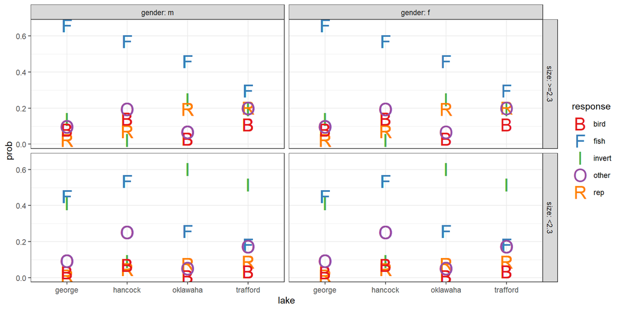

## Other Sources

In addition to the example found in our Course Notes (Chapter 28)…

- A good source of information on fitting these models is https://stats.idre.ucla.edu/r/dae/multinomial-logistic-regression/
- Using the tidymodels structure to fit these models is another good idea. Julia Silge has a very nice example at https://juliasilge.com/blog/multinomial-volcano-eruptions/
- More mathematically oriented sources include the following texts:
  - Hosmer DW Lemeshow S Sturdivant RX (2013) Applied Logistic Regression, 3rd Edition, Wiley
  - Agresti A (2007) An Introduction to Categorical Data Analysis, 2nd Edition, Wiley.

## Next Time

A *very* brief introduction to hierarchical models for data

432 Class 19 | 2024-03-26 | https://thomaselove.github.io/432-2024/